# Name : Aiyanna K R

PROJECT NAME : INSURENCE COST PERDICTION

# Insurance Cost Prediction Problem Statement

The insurance cost prediction problem involves developing a model that can accurately predict the cost of insurance premiums for individuals based on various factors such as age, gender, medical history, charges, and other relevant information.

The objective of this problem is to build a predictive model that can help insurance companies determine the risk associated with an individual and set premiums accordingly. The model should be able to accurately predict insurance costs for new customers based on their individual characteristics, as well as help insurance companies identify and manage high-risk customers.

To solve this problem, the data scientist will need to collect and preprocess the relevant data, explore the data to identify any patterns or correlations, select appropriate features, and build and test various machine learning models to identify the best-performing model for this task. The model's accuracy will be evaluated based on metrics such as mean squared error, mean absolute error, and R-squared.

# Deseription

The objective of this insurence dataset is to predict charges the datsets consists of several predictor variables and one target variable

# Import library

```python
import pandas as pd
import numpy as np
import warnings
warnings.filterwarnings('ignore')
import seaborn as sns
import matplotlib.pyplot as plt
```

# Load the dataset

```python
insurence = pd.read_csv("insurance.csv")
```

# EXPLORATORY DATA ANALYSIS

```python
#1st 5 record display
insurence.head()
```

|  | age | sex | bmi | children | smoker | region | charges |
| --- | --- | --- | --- | --- | --- | --- | --- |
| 0 | 19 | female | 27.900 | 0 | yes | southwest | 16884.92400 |
| 1 | 18 | male | 33.770 | 1 | no | southeast | 1725.55230 |
| 2 | 28 | male | 33.000 | 3 | no | southeast | 4449.46200 |
| 3 | 33 | male | 22.705 | 0 | no | northwest | 21984.47061 |
| 4 | 32 | male | 28.880 | 0 | no | northwest | 3866.85520 |

```python
#last 5record display
insurence.tail()
```

|  | age | sex | bmi | children | smoker | region | charges |
| --- | --- | --- | --- | --- | --- | --- | --- |
| 1333 | 50 | male | 30.97 | 3 | no | northwest | 10600.5483 |
| 1334 | 18 | female | 31.92 | 0 | no | northeast | 2205.9808 |
| 1335 | 18 | female | 36.85 | 0 | no | southeast | 1629.8335 |
| 1336 | 21 | female | 25.80 | 0 | no | southwest | 2007.9450 |
| 1337 | 61 | female | 29.07 | 0 | yes | northwest | 29141.3603 |

```python
insurence.shape
```

```
(1338, 7)
```

```python
insurence.info()
```

```
<class 'pandas.core.frame.DataFrame'>
RangeIndex: 1338 entries, 0 to 1337
Data columns (total 7 columns):
 #   Column    Non-Null Count  Dtype
---  ------    --------------  -----
 0   age       1338 non-null   int64
 1   sex       1338 non-null   object
 2   bmi       1338 non-null   float64
 3   children  1338 non-null   int64
 4   smoker    1338 non-null   object
 5   region    1338 non-null   object
 6   charges   1338 non-null   float64
dtypes: float64(2), int64(2), object(3)
memory usage: 73.3+ KB
```

```python
insurence.isna().sum()
```

```
age         0
sex         0
bmi         0
children    0
smoker      0
region      0
charges     0
dtype: int64
```

# summary of the dataset

the discribed method will help to see how data has been spread for numerical value. we can clearly see the minimum value mean values different percentile value and meximem value

```python
#statistical summary
insurence.describe()
```

|  | age | bmi | children | charges |
| --- | --- | --- | --- | --- |
| count | 1338.000000 | 1338.000000 | 1338.000000 | 1338.000000 |
| mean | 39.207025 | 30.663397 | 1.094918 | 13270.422265 |
| std | 14.049960 | 6.098187 | 1.205493 | 12110.011237 |
| min | 18.000000 | 15.960000 | 0.000000 | 1121.873900 |
| 25% | 27.000000 | 26.296250 | 0.000000 | 4740.287150 |
| 50% | 39.000000 | 30.400000 | 1.000000 | 9382.033000 |
| 75% | 51.000000 | 34.693750 | 2.000000 | 16639.912515 |
| max | 64.000000 | 53.130000 | 5.000000 | 63770.428010 |

```python
#numerical features
[features for features in insurence.dtypes[insurence.dtypes != 'object'].index]
```

```
['age', 'bmi', 'children', 'charges']
```

```python
num_features =  insurence.dtypes[insurence.dtypes != 'object'].index
```

```python
#distribution of categorical features
cat_features= insurence.dtypes[insurence.dtypes == 'object'].index
cat_features
```

```
Index(['sex', 'smoker', 'region'], dtype='object')
```

```python
insurence[cat_features].describe()
```

|  | sex | smoker | region |
| --- | --- | --- | --- |
| count | 1338 | 1338 | 1338 |
| unique | 2 | 2 | 4 |
| top | male | no | southeast |
| freq | 676 | 1064 | 364 |

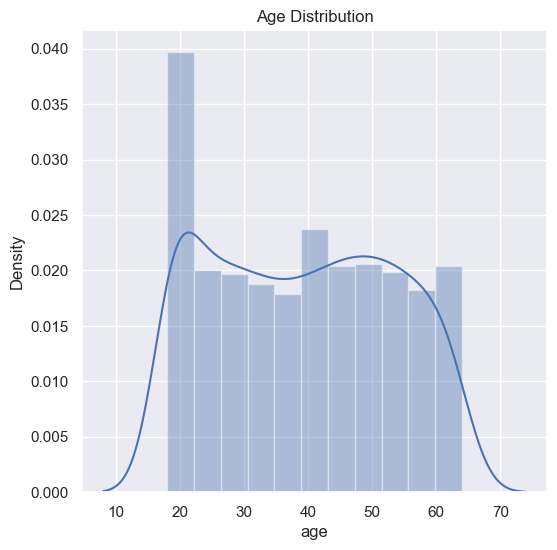

```python
#distribution of age vlaue
sns.set()
plt.figure(figsize=(6,6))
sns.distplot(insurence['age'])
plt.title('Age Distribution')
plt.show()
```

```python
insurence['sex'].unique()
```

```
array(['female', 'male'], dtype=object)
```

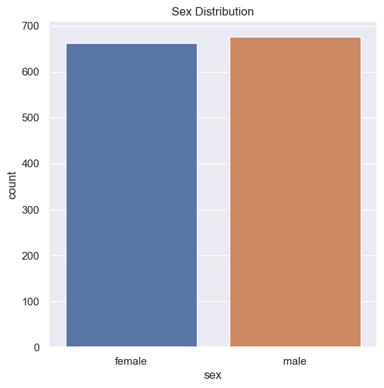

```python
plt.figure(figsize=(6,6))
sns.countplot(x='sex',data=insurence)
plt.title('Sex Distribution')
plt.show()
```

```python
insurence['sex'].value_counts()
```

```
male      676
female    662
Name: sex, dtype: int64
```

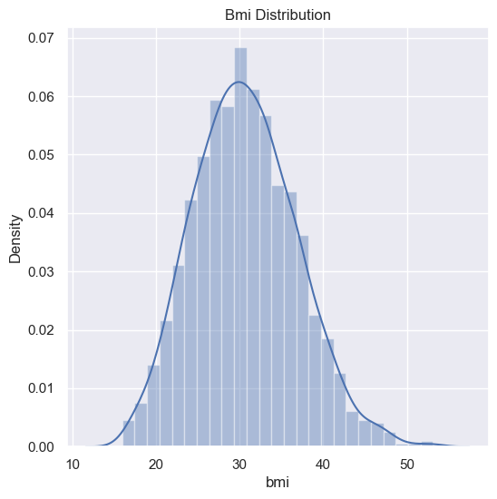

```python
#distribution of age vlaue
sns.set()
plt.figure(figsize=(6,6))
sns.distplot(insurence['bmi'])
plt.title('Bmi Distribution')
plt.show()
```

```python
insurence['children'].value_counts()
```

```
0    574
1    324
2    240
3    157
4     25
5     18
Name: children, dtype: int64
```

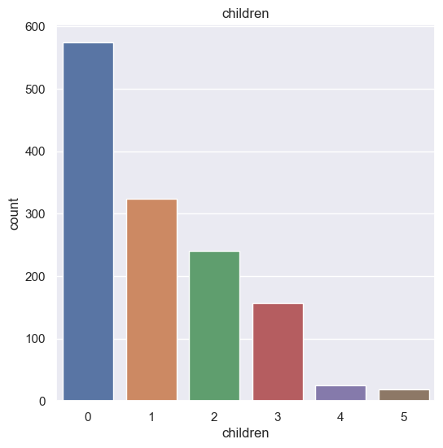

```python
#children column
plt.figure(figsize=(6,6))
sns.countplot(x='children',data=insurence)
plt.title('children')
plt.show()
```

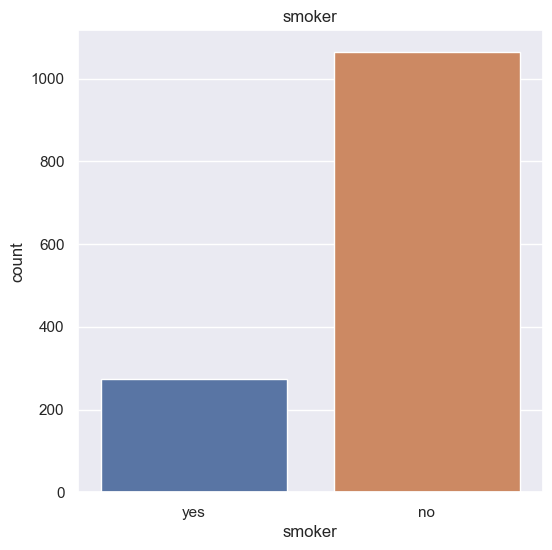

```python
#children column
plt.figure(figsize=(6,6))
sns.countplot(x='smoker',data=insurence)
plt.title('smoker')
plt.show()
```

```python
insurence['smoker'].value_counts()
```

```
no     1064
yes     274
Name: smoker, dtype: int64
```

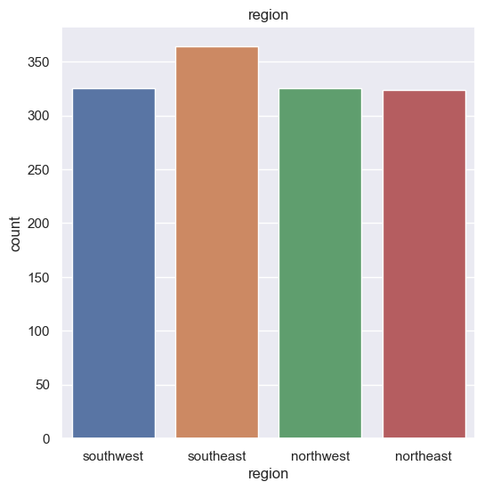

```python
#children column
plt.figure(figsize=(6,6))
sns.countplot(x='region',data=insurence)
plt.title('region')
plt.show()
```

```python
insurence['region'].value_counts()
```

```
southeast    364
southwest    325
northwest    325
northeast    324
Name: region, dtype: int64
```

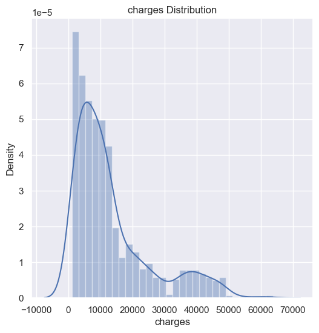

```python
#distribution of age vlaue
sns.set()
plt.figure(figsize=(6,6))
sns.distplot(insurence['charges'])
plt.title('charges Distribution')
plt.show()
```

# Data Pre-processing

Converting categorical variable to numerical variable

Apply get dummies method

this is one of the approch and an each one of the encode catagorical data pandas get_dummies() method takes catagorical feature as argument then it creates a dummy variable for verey labele in the feature such that each dummy variable holds data as 1 or 0. 1 indicates the presence of particular label and 0 indicates the absence of particular label

For example if feature contains lables as male and female after applying pandas get_dummies ()to the feature Dummy variable for both male and female labels are created

```python
dummies=pd.get_dummies(insurence.sex)
```

```python
dummies.head()
```

|  | female | male |
| --- | --- | --- |
| 0 | 1 | 0 |
| 1 | 0 | 1 |
| 2 | 0 | 1 |
| 3 | 0 | 1 |
| 4 | 0 | 1 |

```python
insurence.head()
```

|  | age | sex | bmi | children | smoker | region | charges |
| --- | --- | --- | --- | --- | --- | --- | --- |
| 0 | 19 | female | 27.900 | 0 | yes | southwest | 16884.92400 |
| 1 | 18 | male | 33.770 | 1 | no | southeast | 1725.55230 |
| 2 | 28 | male | 33.000 | 3 | no | southeast | 4449.46200 |
| 3 | 33 | male | 22.705 | 0 | no | northwest | 21984.47061 |
| 4 | 32 | male | 28.880 | 0 | no | northwest | 3866.85520 |

```python
merge = pd.concat([insurence,dummies],axis=1)
merge.head()
```

|  | age | sex | bmi | children | smoker | region | charges | female | male |
| --- | --- | --- | --- | --- | --- | --- | --- | --- | --- |
| 0 | 19 | female | 27.900 | 0 | yes | southwest | 16884.92400 | 1 | 0 |
| 1 | 18 | male | 33.770 | 1 | no | southeast | 1725.55230 | 0 | 1 |
| 2 | 28 | male | 33.000 | 3 | no | southeast | 4449.46200 | 0 | 1 |
| 3 | 33 | male | 22.705 | 0 | no | northwest | 21984.47061 | 0 | 1 |
| 4 | 32 | male | 28.880 | 0 | no | northwest | 3866.85520 | 0 | 1 |

```python
insurence1=merge.drop(['sex','female'],axis=1)
insurence1.head()
```

|  | age | bmi | children | smoker | region | charges | male |
| --- | --- | --- | --- | --- | --- | --- | --- |
| 0 | 19 | 27.900 | 0 | yes | southwest | 16884.92400 | 0 |
| 1 | 18 | 33.770 | 1 | no | southeast | 1725.55230 | 1 |
| 2 | 28 | 33.000 | 3 | no | southeast | 4449.46200 | 1 |
| 3 | 33 | 22.705 | 0 | no | northwest | 21984.47061 | 1 |
| 4 | 32 | 28.880 | 0 | no | northwest | 3866.85520 | 1 |

```python
dummi1=pd.get_dummies(insurence1.smoker)
dummi1.head()
```

|  | no | yes |
| --- | --- | --- |
| 0 | 0 | 1 |
| 1 | 1 | 0 |
| 2 | 1 | 0 |
| 3 | 1 | 0 |
| 4 | 1 | 0 |

```python
merge1 = pd.concat([insurence1,dummi1],axis=1)
insurence2=merge1.drop(['smoker','no'],axis=1)
insurence2.head()
```

|  | age | bmi | children | region | charges | male | yes |
| --- | --- | --- | --- | --- | --- | --- | --- |
| 0 | 19 | 27.900 | 0 | southwest | 16884.92400 | 0 | 1 |
| 1 | 18 | 33.770 | 1 | southeast | 1725.55230 | 1 | 0 |
| 2 | 28 | 33.000 | 3 | southeast | 4449.46200 | 1 | 0 |
| 3 | 33 | 22.705 | 0 | northwest | 21984.47061 | 1 | 0 |
| 4 | 32 | 28.880 | 0 | northwest | 3866.85520 | 1 | 0 |

```python
dummi2=pd.get_dummies(insurence2.region)
dummi2.head()
```

|  | northeast | northwest | southeast | southwest |
| --- | --- | --- | --- | --- |
| 0 | 0 | 0 | 0 | 1 |
| 1 | 0 | 0 | 1 | 0 |
| 2 | 0 | 0 | 1 | 0 |
| 3 | 0 | 1 | 0 | 0 |
| 4 | 0 | 1 | 0 | 0 |

```python
merge2 = pd.concat([insurence2,dummi2],axis=1)
merge2.head()
```

|  | age | bmi | children | region | charges | male | yes | northeast | northwest | southeast | southwest |
| --- | --- | --- | --- | --- | --- | --- | --- | --- | --- | --- | --- |
| 0 | 19 | 27.900 | 0 | southwest | 16884.92400 | 0 | 1 | 0 | 0 | 0 | 1 |
| 1 | 18 | 33.770 | 1 | southeast | 1725.55230 | 1 | 0 | 0 | 0 | 1 | 0 |
| 2 | 28 | 33.000 | 3 | southeast | 4449.46200 | 1 | 0 | 0 | 0 | 1 | 0 |
| 3 | 33 | 22.705 | 0 | northwest | 21984.47061 | 1 | 0 | 0 | 1 | 0 | 0 |
| 4 | 32 | 28.880 | 0 | northwest | 3866.85520 | 1 | 0 | 0 | 1 | 0 | 0 |

```python
insurence3=merge2.drop(['region','northeast'],axis=1)
insurence3.head()
```

|  | age | bmi | children | charges | male | yes | northwest | southeast | southwest |
| --- | --- | --- | --- | --- | --- | --- | --- | --- | --- |
| 0 | 19 | 27.900 | 0 | 16884.92400 | 0 | 1 | 0 | 0 | 1 |
| 1 | 18 | 33.770 | 1 | 1725.55230 | 1 | 0 | 0 | 1 | 0 |
| 2 | 28 | 33.000 | 3 | 4449.46200 | 1 | 0 | 0 | 1 | 0 |
| 3 | 33 | 22.705 | 0 | 21984.47061 | 1 | 0 | 1 | 0 | 0 |
| 4 | 32 | 28.880 | 0 | 3866.85520 | 1 | 0 | 1 | 0 | 0 |

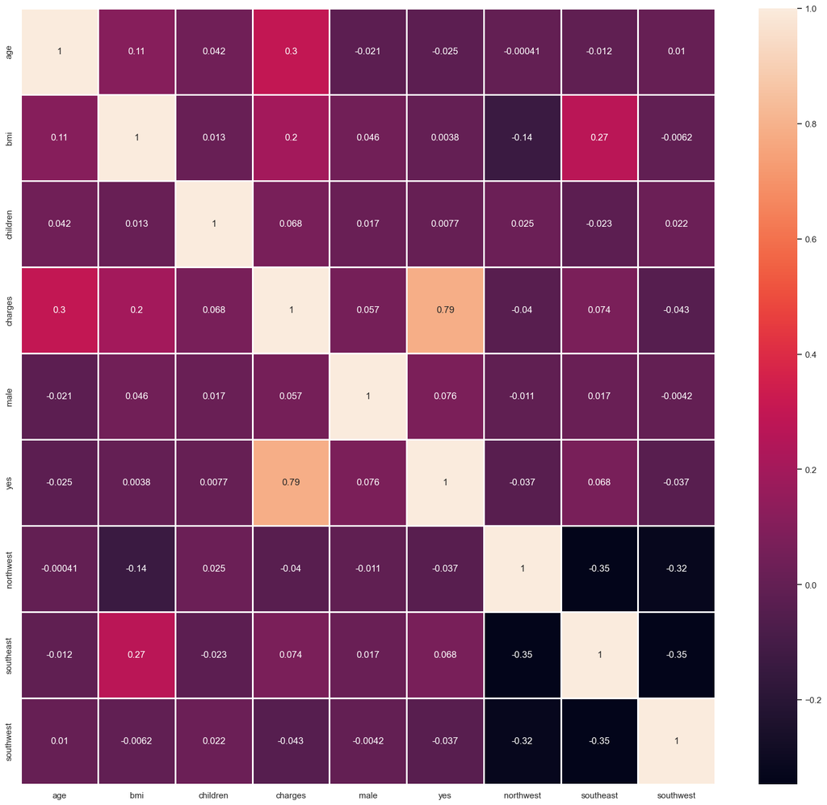

```python
import matplotlib.pyplot as plt
plt.figure(figsize = (20, 18))
sns.heatmap(data = insurence3.corr(), annot = True, fmt = '.2g', linewidth = 1)
plt.show()
```

```python
insurence3.shape
```

```
(1338, 9)
```

# Split the data into X & Y

```python
target_name = 'charges'

#suparate object for target feature
y = insurence3[target_name]

##suparate object for input feature
X = insurence3.drop(target_name, axis=1)
```

```python
X.head()
```

|  | age | bmi | children | male | yes | northwest | southeast | southwest |
| --- | --- | --- | --- | --- | --- | --- | --- | --- |
| 0 | 19 | 27.900 | 0 | 0 | 1 | 0 | 0 | 1 |
| 1 | 18 | 33.770 | 1 | 1 | 0 | 0 | 1 | 0 |
| 2 | 28 | 33.000 | 3 | 1 | 0 | 0 | 1 | 0 |
| 3 | 33 | 22.705 | 0 | 1 | 0 | 1 | 0 | 0 |
| 4 | 32 | 28.880 | 0 | 1 | 0 | 1 | 0 | 0 |

```python
X.shape
```

```
(1338, 8)
```

```python
y.head()
```

```
0    16884.92400
1     1725.55230
2     4449.46200
3    21984.47061
4     3866.85520
Name: charges, dtype: float64
```

# Train Test Split

```python
from sklearn.model_selection import train_test_split
X_train, X_test, y_train, y_test = train_test_split(X, y, test_size=0.2, random_state =7)
```

```python
X_train.shape,y_train.shape
```

```
((1070, 8), (1070,))
```

```python
X_test.shape, y_test.shape
```

```
((268, 8), (268,))
```

# Build the Regression Algorithms

```python
from sklearn.linear_model import LinearRegression
lr = LinearRegression()
lr.fit(X_train,y_train)
y_pred = lr.predict(X_test)
```

# Evaluation metrics

```python
train_score=lr.score(X_train,y_train)
print('Train score:',train_score)
```

```
Train score: 0.7467955093844898
```

```python
from sklearn.metrics import r2_score
score=r2_score(y_test,y_pred)
print('r_2 score',score)
```

```
r_2 score 0.7638170729823931
```

```python
from sklearn import metrics
print('mean Absolute Error:',metrics.mean_absolute_error(y_test,y_pred))
print('mean squared Error:',metrics.mean_squared_error(y_test,y_pred))
print('Rootb mean squared Error:',np.sqrt(metrics.mean_absolute_error(y_test,y_pred)))
```

[output not shown]

```python
insurence4=pd.DataFrame({'Actual':y_test,'predicted':y_pred,'variance':y_test-y_pred})
insurence4.head()
```

|  | Actual | predicted | variance |
| --- | --- | --- | --- |
| 13 | 11090.7178 | 15031.716690 | -3940.998890 |
| 1052 | 9288.0267 | 11145.229685 | -1857.202985 |
| 172 | 1694.7964 | -1898.911344 | 3593.707744 |
| 1085 | 19023.2600 | 29168.236689 | -10144.976689 |
| 683 | 9863.4718 | 9037.538010 | 825.933790 |

```python
insurence3.head(14)
```

|  | age | bmi | children | charges | male | yes | northwest | southeast | southwest |
| --- | --- | --- | --- | --- | --- | --- | --- | --- | --- |
| 0 | 19 | 27.900 | 0 | 16884.92400 | 0 | 1 | 0 | 0 | 1 |
| 1 | 18 | 33.770 | 1 | 1725.55230 | 1 | 0 | 0 | 1 | 0 |
| 2 | 28 | 33.000 | 3 | 4449.46200 | 1 | 0 | 0 | 1 | 0 |
| 3 | 33 | 22.705 | 0 | 21984.47061 | 1 | 0 | 1 | 0 | 0 |
| 4 | 32 | 28.880 | 0 | 3866.85520 | 1 | 0 | 1 | 0 | 0 |
| 5 | 31 | 25.740 | 0 | 3756.62160 | 0 | 0 | 0 | 1 | 0 |
| 6 | 46 | 33.440 | 1 | 8240.58960 | 0 | 0 | 0 | 1 | 0 |
| 7 | 37 | 27.740 | 3 | 7281.50560 | 0 | 0 | 1 | 0 | 0 |
| 8 | 37 | 29.830 | 2 | 6406.41070 | 1 | 0 | 0 | 0 | 0 |
| 9 | 60 | 25.840 | 0 | 28923.13692 | 0 | 0 | 1 | 0 | 0 |
| 10 | 25 | 26.220 | 0 | 2721.32080 | 1 | 0 | 0 | 0 | 0 |
| 11 | 62 | 26.290 | 0 | 27808.72510 | 0 | 1 | 0 | 1 | 0 |
| 12 | 23 | 34.400 | 0 | 1826.84300 | 1 | 0 | 0 | 0 | 1 |
| 13 | 56 | 39.820 | 0 | 11090.71780 | 0 | 0 | 0 | 1 | 0 |

```python
lr.predict([[56,39.820,0,0,0,0,1,0]])
```

```
array([15031.71668981])
```

```python
print('intercept',lr.intercept_)
```

```
intercept -11735.182608530404
```

```python
print('coefficients',lr.coef_)
```

```
coefficients [  251.29111226   345.21530565   465.98025996  -196.60503448
 23540.74666667  -744.73953022 -1051.87645938 -1085.02214042]
```

# Bulilding optimal model using Backward Elimiation Method

when we are buliding a machine learning model it is very importnt we select only those features or predictors which are necessary suppose we have 50 feature or predictors on our dataset that dose not necessary mean that we need to have all 50 feature in our model there are verious ways in which you can find out which feature have very littel impact on the model and which ones you can remove from your dataset

A similar idea can be applied in Backward Elimiation weather a feature significantly impacts the output or not A p-value helps detemine weather a hypothosis must be accepred of rejected

```python
 import statsmodels.api as sm
```

```python
X.head()
```

|  | age | bmi | children | male | yes | northwest | southeast | southwest |
| --- | --- | --- | --- | --- | --- | --- | --- | --- |
| 0 | 19 | 27.900 | 0 | 0 | 1 | 0 | 0 | 1 |
| 1 | 18 | 33.770 | 1 | 1 | 0 | 0 | 1 | 0 |
| 2 | 28 | 33.000 | 3 | 1 | 0 | 0 | 1 | 0 |
| 3 | 33 | 22.705 | 0 | 1 | 0 | 1 | 0 | 0 |
| 4 | 32 | 28.880 | 0 | 1 | 0 | 1 | 0 | 0 |

```python
X.shape
```

```
(1338, 8)
```

the equation of our line is y=b+m1x1+m2x2+m3x3+m4x4 when we make a linear model with sklearn the bias from b is calculated separetely

```python
#column of ones as integer data type
X1=np.append(arr=np.ones((1338,1)).astype(int),values=X,axis=1)
```

```python
X1.shape
```

```
(1338, 9)
```

```python
X1
```

```
array([[ 1.  , 19.  , 27.9 , ...,  0.  ,  0.  ,  1.  ],
       [ 1.  , 18.  , 33.77, ...,  0.  ,  1.  ,  0.  ],
       [ 1.  , 28.  , 33.  , ...,  0.  ,  1.  ,  0.  ],
       ...,
       [ 1.  , 18.  , 36.85, ...,  0.  ,  1.  ,  0.  ],
       [ 1.  , 21.  , 25.8 , ...,  0.  ,  0.  ,  1.  ],
       [ 1.  , 61.  , 29.07, ...,  1.  ,  0.  ,  0.  ]])
```

```python
# choose a significanc level usually 0.05,if p>0.05
#for the highest values parameter remove that value
X_opt=X1[:,[0,1,2,3,4,5,6,7,8,]]
X_opt.shape
```

```
(1338, 9)
```

```python
X.head()
```

|  | age | bmi | children | male | yes | northwest | southeast | southwest |
| --- | --- | --- | --- | --- | --- | --- | --- | --- |
| 0 | 19 | 27.900 | 0 | 0 | 1 | 0 | 0 | 1 |
| 1 | 18 | 33.770 | 1 | 1 | 0 | 0 | 1 | 0 |
| 2 | 28 | 33.000 | 3 | 1 | 0 | 0 | 1 | 0 |
| 3 | 33 | 22.705 | 0 | 1 | 0 | 1 | 0 | 0 |
| 4 | 32 | 28.880 | 0 | 1 | 0 | 1 | 0 | 0 |

```python
X_opt
```

```
array([[ 1.  , 19.  , 27.9 , ...,  0.  ,  0.  ,  1.  ],
       [ 1.  , 18.  , 33.77, ...,  0.  ,  1.  ,  0.  ],
       [ 1.  , 28.  , 33.  , ...,  0.  ,  1.  ,  0.  ],
       ...,
       [ 1.  , 18.  , 36.85, ...,  0.  ,  1.  ,  0.  ],
       [ 1.  , 21.  , 25.8 , ...,  0.  ,  0.  ,  1.  ],
       [ 1.  , 61.  , 29.07, ...,  1.  ,  0.  ,  0.  ]])
```

```python
X_opt[:,0]
```

```
array([1., 1., 1., ..., 1., 1., 1.])
```

```python
# age 1st column
X_opt[:,1]
```

```
array([19., 18., 28., ..., 18., 21., 61.])
```

```python
#bmi 2nd column
X_opt[:,2]
```

```
array([27.9 , 33.77, 33.  , ..., 36.85, 25.8 , 29.07])
```

```python
#children 3rd column
X_opt[:,3]
```

```
array([0., 1., 3., ..., 0., 0., 0.])
```

```python
#male 4th column
X_opt[:,4]
```

```
array([0., 1., 1., ..., 0., 0., 0.])
```

```python
# yes 5th column
X_opt[:,5]
```

```
array([1., 0., 0., ..., 0., 0., 1.])
```

```python
#northwest 6th column
X_opt[:,6]
```

```
array([0., 0., 0., ..., 0., 0., 1.])
```

```python
#southeast 7th column
X_opt[:,7]
```

```
array([0., 1., 1., ..., 1., 0., 0.])
```

```python
#southeast 8th column
X_opt[:,8]
```

```
array([1., 0., 0., ..., 0., 1., 0.])
```